# Phylogeny of Columbidae

```r
library(phytools)
library(dplyr)
library(tidyverse)
rm(list = ls())
```

Load a maximum clade credibility tree from jetz

```r
tree <- read.tree("./phylogeny__stage2_hackett_mcc_no_neg.tre")
```

Load urban tolerance data

```r
col_ut <- read_csv('./bigquery_export__columbidae_jetz_urban_tolerance.csv')
```

Check for species from data not in tree

```r
col_ut[!col_ut$jetz_scientific_name %in% tree$tip.label,]
```

| jetz_scientific_name | region_count | city_count | urban_tolerance |
| --- | --- | --- | --- |

Number of species in analysis:

```r
nrow(col_ut)
```

```
[1] 160
```

Format data

```r
columbidae_input_species <- col_ut[col_ut$jetz_scientific_name %in% tree$tip.label,]
tree_pruned_to_columbidae <- ladderize(drop.tip(tree, setdiff(tree$tip.label, col_ut$jetz_scientific_name)))

columbidae_response <- columbidae_input_species$urban_tolerance
names(columbidae_response) <- columbidae_input_species$jetz_scientific_name

head(columbidae_response)
```

```
 Macropygia_tenuirostris            Ducula_carola      Ducula_poliocephala   Gallicolumba_crinigera   Ptilinopus_occipitalis Phapitreron_amethystinus
                       1                        1                        0                        0                        0                        0
```

Is the a phylogenetic signal for urban tolerance in the columbidae family

```r
col_ut_phylo_signal <- phylosig(tree_pruned_to_columbidae, columbidae_response, method="lambda", test=TRUE)
col_ut_phylo_signal
```

```
Phylogenetic signal lambda : 0.163399
logL(lambda) : -43.2776
LR(lambda=0) : 2.34299
P-value (based on LR test) : 0.125847
```

[output not shown]

Show the results for species

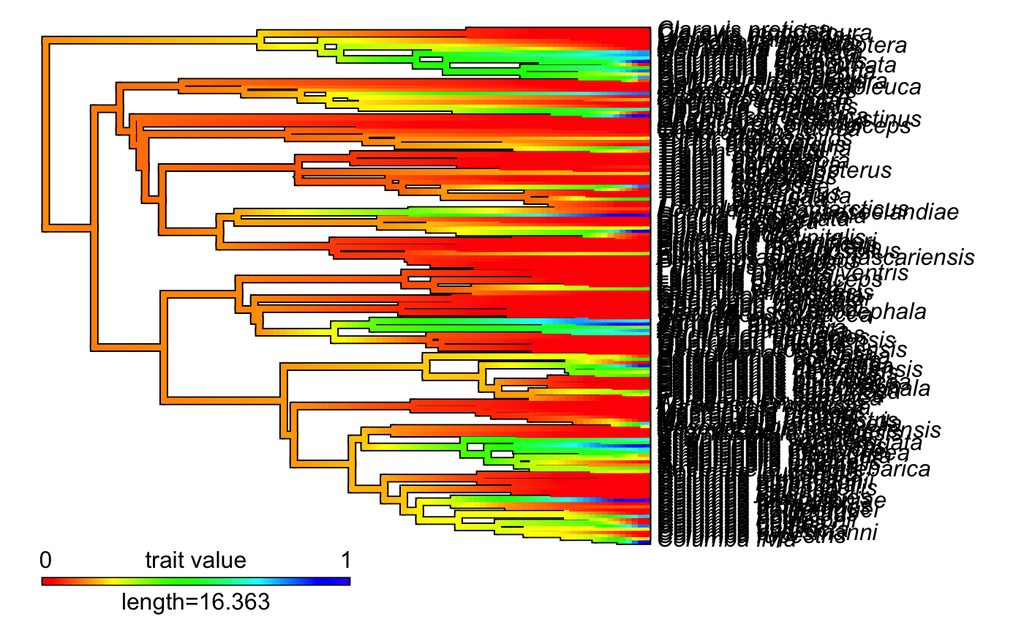

```r
col_continuous_trait_evolution <- contMap(tree_pruned_to_columbidae, columbidae_response)
```

```r
colourCount <- length(col_continuous_trait_evolution$cols)
col_continuous_trait_evolution$cols[1:colourCount] <- rev(col_continuous_trait_evolution$col[1:colourCount])
```

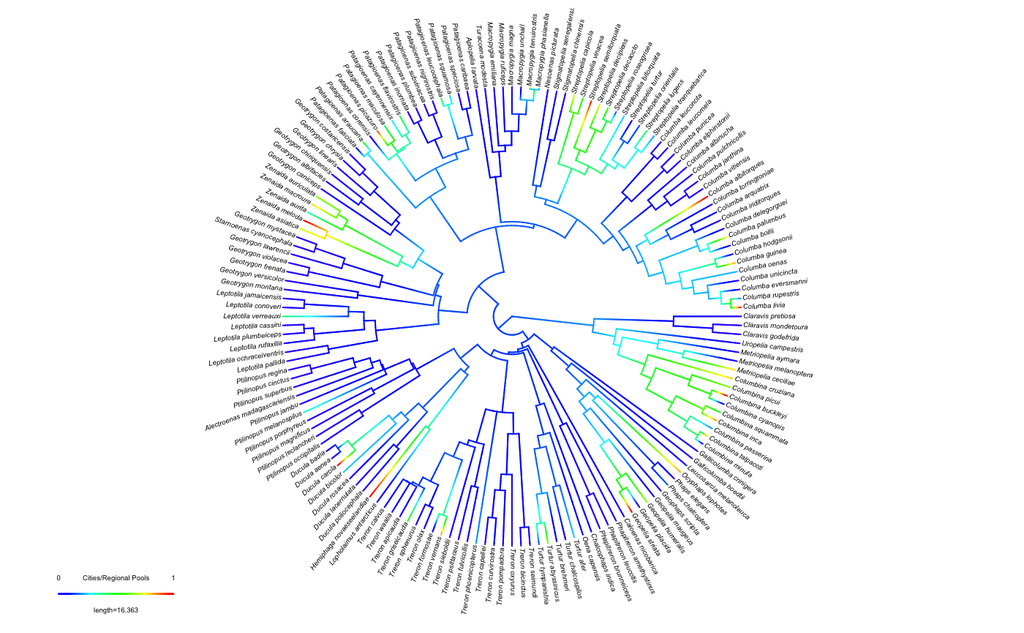

```r
cte_all = plot(col_continuous_trait_evolution, outline=FALSE, fsize=0.3, lwd=1, leg.txt="Cities/Regional Pools", type = "fan")
```

```r
cte_all
```

```
[1] 0
```

## Find the age of each species (tip branch length)

```r
species_ages = tree_pruned_to_columbidae$edge.length[tree_pruned_to_columbidae$edge[, 2] %in% 1:Ntip(tree_pruned_to_columbidae)]
tips <- tree_pruned_to_columbidae$edge[tree_pruned_to_columbidae$edge[, 2] %in%  1:Ntip(tree_pruned_to_columbidae), 2]
names(species_ages) = tree_pruned_to_columbidae$tip.label[tips]
species_ages
```

```
               Columba_livia            Columba_rupestris           Columba_eversmanni            Columba_unicincta                Columba_oenas               Columba_guinea
                   1.4344391                    1.4344391                    2.7830221                    4.5011378                    6.5337619                    2.6611178
           Columba_hodgsonii               Columba_bollii             Columba_palumbus          Columba_delegorguei         Columba_iriditorques            Columba_arquatrix
                   2.6611178                    3.0176922                    3.0176922                    4.3466447                    4.0675533                    4.0675533
       Columba_torringtoniae          Columba_albitorques            Columba_vitiensis             Columba_janthina        Columba_pulchricollis            Columba_albinucha
                   7.5432767                   10.4922742                    2.3042157                    2.3042157                    5.1111607                    7.2045460
        Columba_elphinstonii              Columba_punicea            Columba_leucomela            Columba_leuconota   Streptopelia_tranquebarica          Streptopelia_lugens
                   2.5761616                    2.5761616                    2.1491747                    2.1491747                    2.9325217                    2.9325217
     Streptopelia_orientalis          Streptopelia_turtur      Streptopelia_bitorquata     Streptopelia_roseogrisea        Streptopelia_decaocto       Streptopelia_decipiens
                   3.0392187                    3.0392187                    7.0586882                    1.7191993                    1.7191993                    3.5625193
   Streptopelia_semitorquata         Streptopelia_vinacea        Streptopelia_capicola      Stigmatopelia_chinensis   Stigmatopelia_senegalensis           Nesoenas_picturata
                   7.0979513                    2.3458287                    2.3458287                    6.9340840                    6.9340840                   13.7495541
      Macropygia_phasianella      Macropygia_tenuirostris           Macropygia_unchall             Macropygia_magna          Macropygia_ruficeps          Macropygia_emiliana
                   0.1896371                    0.1896371                    1.7931040                    3.8489391                    6.3011111                    8.3051048
           Turacoena_modesta            Aplopelia_larvata         Patagioenas_caribaea         Patagioenas_speciosa         Patagioenas_squamosa     Patagioenas_leucocephala
                   9.1377218                   12.6871636                    2.3917337                    2.3917337                    1.1849168                    1.1849168
    Patagioenas_nigrirostris       Patagioenas_subvinacea          Patagioenas_plumbea         Patagioenas_inornata     Patagioenas_flavirostris      Patagioenas_cayennensis
                   1.7684913                    1.7684913                    1.8959606                    1.8959606                    2.6616050                    2.6616050
        Patagioenas_maculosa         Patagioenas_picazuro         Patagioenas_corensis         Patagioenas_araucana         Patagioenas_fasciata      Geotrygon_costaricensis
                   2.5570197                    2.5570197                    4.2785159                    1.6532703                    1.6532703                    3.0984709
           Geotrygon_chrysia           Geotrygon_linearis       Geotrygon_chiriquensis         Geotrygon_albifacies           Geotrygon_caniceps           Zenaida_auriculata
                   3.0984709                    6.1130281                    5.6328981                    5.6328981                   11.8297875                    3.9607505
            Zenaida_macroura               Zenaida_aurita               Zenaida_meloda             Zenaida_asiatica           Geotrygon_mystacea      Starnoenas_cyanocephala
                   3.9607505                    5.5597135                    3.7437029                    3.7437029                    3.0076977                    3.0076977
```

[output cut: 30 more lines]

## What about species in very few regional pools?

```r
ggplot(col_ut, aes(x = region_count)) + geom_bar()
```

[output not shown]

```r
columbidae_reduced_input_species <- col_ut[col_ut$region_count > 5,]
columbidae_reduced_input_species <- columbidae_reduced_input_species[columbidae_reduced_input_species$jetz_scientific_name %in% tree$tip.label,]
tree_pruned_to_columbidae_reduced <- ladderize(drop.tip(tree, setdiff(tree$tip.label, columbidae_reduced_input_species$jetz_scientific_name)))

columbidae_reduced_response <- columbidae_reduced_input_species$urban_tolerance
names(columbidae_reduced_response) <- columbidae_reduced_input_species$jetz_scientific_name

head(columbidae_reduced_response)
```

[output not shown]

```r
col_ut_reduced_phylo_signal <- phylosig(tree_pruned_to_columbidae_reduced, columbidae_reduced_response, method="lambda", test=TRUE)
col_ut_reduced_phylo_signal
```

[output not shown]

Are species in low numbers of regional pool mostly present or absent?

```r
ggplot(col_ut[col_ut$region_count < 5,], aes(x = urban_tolerance)) + geom_bar()
```

[output not shown]

## Is presence explained by number of regions?

```r
summary(lm(formula = urban_tolerance ~ region_count, data = col_ut))
```

[output not shown]

What about for low numbers of regional pools?

```r
summary(lm(formula = urban_tolerance ~ region_count, data = col_ut[col_ut$region_count < 5,]))
```

[output not shown]

What about for higher numbers of regional pools?

```r
summary(lm(formula = urban_tolerance ~ region_count, data = col_ut[col_ut$region_count > 5, ]))
```

[output not shown]

## What about species in at least 5 regional pools?

```r
col_ut5 = col_ut[col_ut$region_count >= 5,]
```

```r
columbidae5_input_species <- col_ut5[col_ut5$jetz_scientific_name %in% tree$tip.label,]
tree_pruned_to_columbidae5 <- ladderize(drop.tip(tree, setdiff(tree$tip.label, col_ut5$jetz_scientific_name)))

columbidae5_response <- columbidae5_input_species$urban_tolerance
names(columbidae5_response) <- columbidae5_input_species$jetz_scientific_name

head(columbidae5_response)
```

[output not shown]

Is the a phylogenetic signal for urban tolerance in the columbidae family

```r
col_ut5_phylo_signal <- phylosig(tree_pruned_to_columbidae5, columbidae5_response, method="lambda", test=TRUE)
col_ut5_phylo_signal
```

[output not shown]

Show the results for species

```r
col5_continuous_trait_evolution <- contMap(tree_pruned_to_columbidae5, columbidae5_response)

colourCount <- length(col5_continuous_trait_evolution$cols)
col5_continuous_trait_evolution$cols[1:colourCount] <- rev(col5_continuous_trait_evolution$col[1:colourCount])
```

```r
cte_5 = plot(col5_continuous_trait_evolution, outline=FALSE, fsize=0.3, lwd=1, leg.txt="Cities/Regional Pools", type = "fan")
cte_5
```

[output not shown]

### Store CTE plots

```r
par(mfrow=c(1,2))
plot(col_continuous_trait_evolution, outline=FALSE, fsize=0.3, lwd=1, leg.txt="Cities/Regional Pools", type = "fan")
text(0, 65, "All species")
plot(col5_continuous_trait_evolution, outline=FALSE, fsize=0.3, lwd=1, leg.txt="Cities/Regional Pools", type = "fan")
text(0, 60, "Min. 5 regional pools")
```

[output not shown]

```r
jpeg("outputs/phylo.jpg", width = 2056, height = 1024)
par(mfrow=c(1,2))
plot(col_continuous_trait_evolution, outline=FALSE, fsize=0.8, lwd=3, leg.txt="Cities/Regional Pools", type = "fan")
text(0, 46, "All species", cex=2)
plot(col5_continuous_trait_evolution, outline=FALSE, fsize=1, lwd=3, leg.txt="Cities/Regional Pools", type = "fan")
text(0, 49, "Min. 5 regional pools", cex=2)
dev.off()
```

# Using Open Tree of Life

Load a maximum clade credibility tree from open tree https://tree.opentreeoflife.org/opentree/opentree13.4@ott363030/Columbiformes

```r
library(rotl)
```

```r
colu <- read_csv('./bigquery_export__columbidae_birdlife_urban_tolerance.csv')
```

```r
taxa <- tnrs_match_names(unique(colu$species_name), context = "Birds")
```

```r
taxa[!is.na(taxa$unique_name),]
```

```r
opentree <- tol_induced_subtree(ott_id(taxa)[is_in_tree(ott_id(taxa))])
opentree
```

[output not shown]

```r
plot(opentree, show.tip.label = FALSE)
```

[output not shown]

```r
opentree$tip.label[1:4]
```

```r
taxon_map <- structure(taxa$search_string, names = taxa$unique_name)
taxon_map['Streptopelia decaocto']
```

```r
otl_tips <- strip_ott_ids(opentree$tip.label, remove_underscores = TRUE)
opentree$tip.label <- taxon_map[ otl_tips ]
opentree$node.label <- NULL
opentree$tip.label[1:4]
```

Check for species from data not in tree

```r
colu$species_name <- tolower(colu$species_name)
colu[!colu$species_name %in% opentree$tip.label,]
```

Format data

```r
columbidae_2_input_species <- colu[colu$species_name %in% opentree$tip.label,]
opentree_pruned_to_columbidae <- ladderize(drop.tip(opentree, setdiff(opentree$tip.label, colu$species_name)))

columbidae_2_response <- columbidae_2_input_species$urban_tolerance
names(columbidae_2_response) <- columbidae_2_input_species$species_name

head(columbidae_2_response)
```

There are no branch lengths in Open Tree of Life, so this does not work:

```r
colu_phylo_signal <- phylosig(opentree_pruned_to_columbidae, columbidae_2_response, method="lambda", test=TRUE)
colu_phylo_signal
```

There are no branch lengths in Open Tree of Life, so this does not work:

```r
col2_continuous_trait_evolution <- contMap(opentree_pruned_to_columbidae, columbidae_2_response)

colourCount <- length(col2_continuous_trait_evolution$cols)
col2_continuous_trait_evolution$cols[1:colourCount] <- rev(col2_continuous_trait_evolution$col[1:colourCount])
```